# Analyzing Individual BGG Users

Phil Henrickson

2022-01-02

# **Shauneh393’s** BoardGameGeek Collection

This notebook contains a set of analyses for the selected user’s boardgamegeek collection. The bulk of the analysis is focused on building a user-specific predictive model to predict the games that Shauneh393 is likely to own. This enables to ask questions like, based on the games the user currently owns, what games are a good fit for their collection? What upcoming games are they likely to purchase?

This analysis is based on data from BoardGameGeek that was last updated on **2021-12-20.**

# 1 Collection Overview

We can look at a basic description of the number of games that the user owns, has rated, has previously owned, etc.

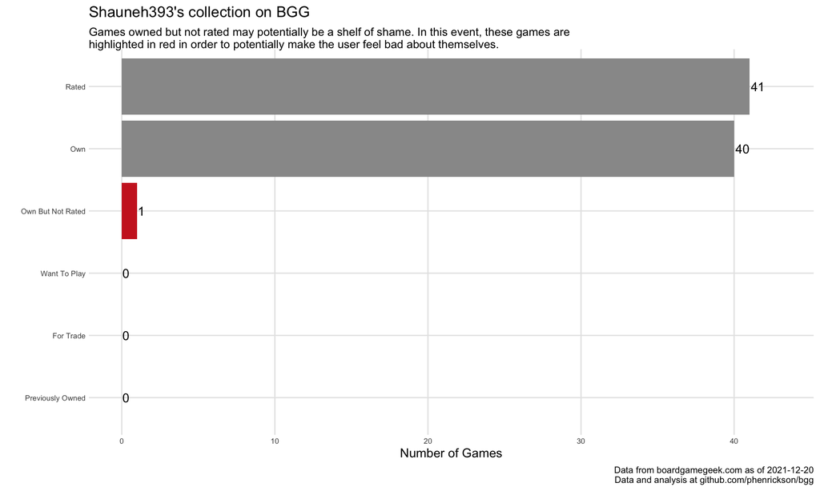

What years has the user owned/rated games from? While we can’t see when a user added or removed a game from their collection, we can look at their collection by the years in which their games were published.

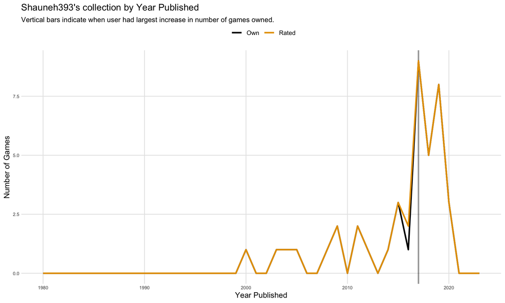

## 1.1 What types of games does Shauneh393 own?

We can look at the most frequent types of categories, mechanics, designers, and artists that appear in a user’s collection.

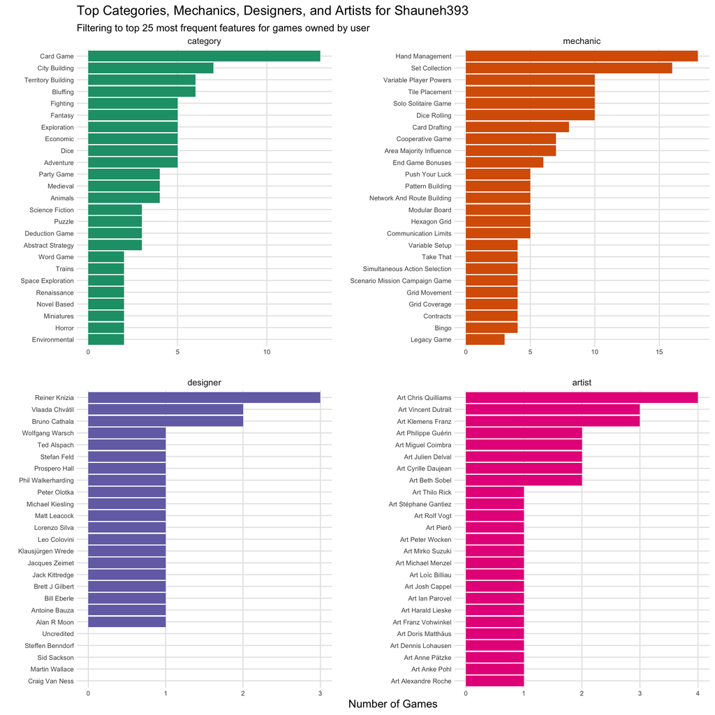

# 2 Modeling **Shauneh393’s** Collection

| username | dataset | period | games_owned | games_rated | games_played |
| --- | --- | --- | --- | --- | --- |
| Shauneh393 | training | published before 2020 | 37 | 38 | 39 |
| Shauneh393 | test | published 2020 or later | 3 | 3 | 3 |

There are two main (binary) outcomes we will be modeling for the user.

The first, **own** refers to whether the user currently lists a game as owned in their collection. The second, **played** refers to whether the user currently owns, has rated, or previously owned a game. This means the latter will generally have a larger list of games, but may still be a useful category to examine for people who play lots of games without necessarily owning them.

We will train predictive models to learn the probability that the user will own or play individual games based on their features.

## 2.1 Coefficients for Shauneh393

We can examine coefficients from the trained modes, which are penalized logistic regressions fit to our two main outcomes. Positive values indicate that a feature increases a user’s probabilility of owning/rating a game, while negative values indicate a feature decreases the probability.

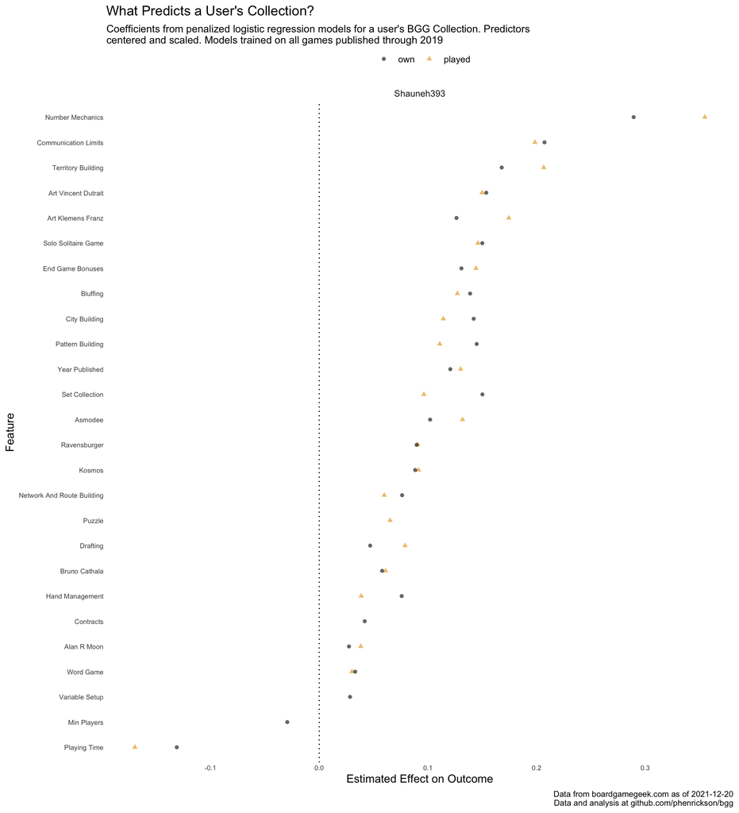

## 2.2 Visualizing Predictors for Shauneh393’s Collection

Why did the model identify these features? We can make density plots of the important features for predicting whether the user owned a game. Blue indicates the density for games owned by the user, while grey indicates the density for games not owned by the user.

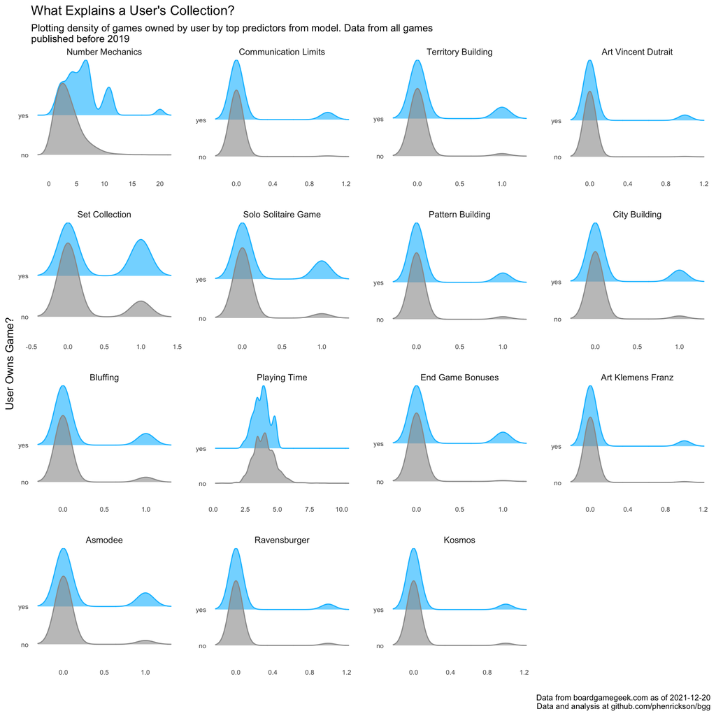

Binary predictors can be difficult to see with this visualization, so we can also directly examine the percentage of games in a user’s collection with a predictor vs the percentage of all games with that predictor.

| username | Feature | % of Games with Feature In_Collection | % of Games with Feature All_Games | Ratio |
| --- | --- | --- | --- | --- |
| Shauneh393 | End Game Bonuses | 16.2% | 1.2% | 13.2 |
| Shauneh393 | Communication Limits | 10.8% | 1.0% | 11.3 |
| Shauneh393 | Contracts | 8.1% | 1.0% | 8.0 |
| Shauneh393 | Drafting | 8.1% | 1.0% | 7.9 |
| Shauneh393 | CMON Global Limited | 5.4% | 0.8% | 6.7 |
| Shauneh393 | Variable Setup | 10.8% | 1.9% | 5.8 |
| Shauneh393 | Environmental | 5.4% | 1.1% | 4.9 |
| Shauneh393 | Territory Building | 16.2% | 3.6% | 4.5 |
| Shauneh393 | Solo Solitaire Game | 24.3% | 5.9% | 4.1 |
| Shauneh393 | City Building | 16.2% | 4.2% | 3.8 |
| Shauneh393 | Line Drawing | 2.7% | 0.7% | 3.7 |
| Shauneh393 | Pattern Building | 13.5% | 3.8% | 3.6 |
| Shauneh393 | Asmodee | 18.9% | 5.4% | 3.5 |
| Shauneh393 | Network And Route Building | 13.5% | 4.1% | 3.3 |
| Shauneh393 | Word Game | 5.4% | 1.8% | 3.1 |
| Shauneh393 | Ravensburger | 8.1% | 3.2% | 2.6 |
| Shauneh393 | Push Your Luck | 13.5% | 5.3% | 2.6 |
| Shauneh393 | Trains | 5.4% | 2.2% | 2.5 |
| Shauneh393 | Bluffing | 16.2% | 6.7% | 2.4 |
| Shauneh393 | Kosmos | 8.1% | 3.3% | 2.4 |
| Shauneh393 | Set Collection | 40.5% | 17.5% | 2.3 |
| Shauneh393 | Hand Management | 45.9% | 26.7% | 1.7 |
| Shauneh393 | Teambased Game | 2.7% | 6.4% | 0.4 |
| Shauneh393 | Movement Points | 0.0% | 1.9% | 0.0 |
| Shauneh393 | Track Movement | 0.0% | 0.7% | 0.0 |

# 3 Assess Model’s Performance on Training Set

Before predicting games in upcoming years, we can examine how well the model did and what games it liked in the training set. In this case, we used resampling techniques (cross validation) to ensure that the model had not seen a game before making its predictions.

## 3.1 Separation Plot

An easy way to examine the performance of classification model is to view a separation plot. We plot the predicted probabilities from the model for every game (from resampling) from lowest to highest. We then overlay a blue line for any game that the user does own. A good classifier is one that is able to *separate* the blue (games owned by the user) from the white (games not owned by the user), with most of the blue occurring at the highest probabilities (right side of the chart).

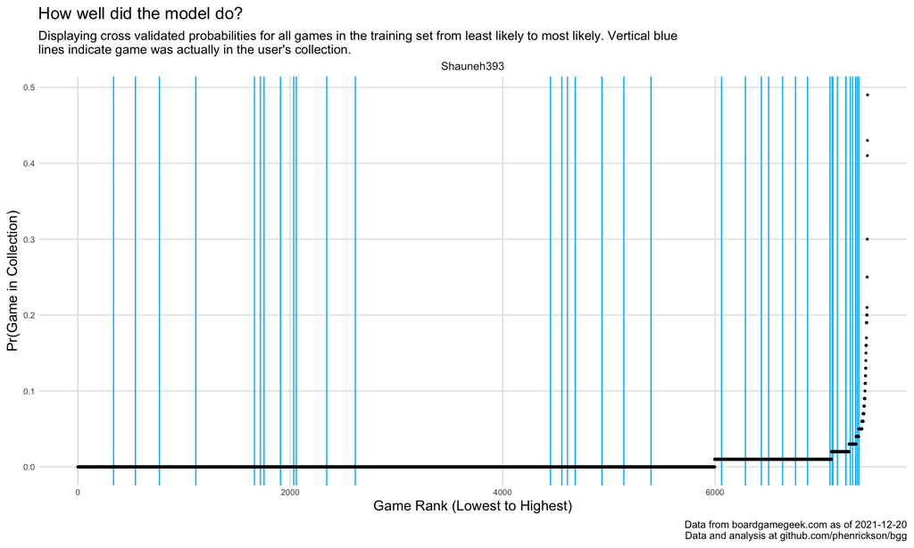

## 3.2 Top Games for **Shauneh393** from Training Set

We can display this information in table form, displaying the 100 games with the highest probability of ownership, adding a blue line when the user does own the game.

| username | yearpublished | game_id | name | pred_played | pred_own | actual_played | actual_own |
| --- | --- | --- | --- | --- | --- | --- | --- |
| Shauneh393 | 2005 | 15062 | Shadows over Camelot | 0.23 | 0.49 | 0 | 0 |
| Shauneh393 | 2012 | 122515 | Keyflower | 0.57 | 0.43 | 0 | 0 |
| Shauneh393 | 2011 | 70919 | Takenoko | 0.47 | 0.41 | 0 | 0 |
| Shauneh393 | 2018 | 258444 | Gingerbread House | 0.09 | 0.30 | 0 | 0 |
| Shauneh393 | 2018 | 205896 | Rising Sun | 0.73 | 0.25 | 0 | 0 |
| Shauneh393 | 2015 | 182874 | Grand Austria Hotel | 0.25 | 0.21 | 0 | 0 |
| Shauneh393 | 2018 | 199792 | Everdell | 0.07 | 0.20 | 0 | 0 |
| Shauneh393 | 2019 | 251247 | Barrage | 0.06 | 0.20 | 0 | 0 |
| Shauneh393 | 2017 | 220308 | Gaia Project | 0.50 | 0.19 | 0 | 0 |
| Shauneh393 | 2019 | 265285 | Queenz: To Bee or Not to Bee | 0.02 | 0.19 | 0 | 0 |
| Shauneh393 | 2016 | 204583 | Kingdomino | 0.02 | 0.19 | 0 | 0 |
| Shauneh393 | 2008 | 35677 | Le Havre | 0.13 | 0.17 | 0 | 0 |
| Shauneh393 | 2019 | 283863 | The Magnificent | 0.18 | 0.16 | 0 | 0 |
| Shauneh393 | 2018 | 231327 | The Grizzled: Armistice Edition | 0.16 | 0.16 | 0 | 0 |
| Shauneh393 | 2014 | 156129 | Deception: Murder in Hong Kong | 0.09 | 0.16 | 0 | 0 |
| Shauneh393 | 2018 | 244711 | Newton | 0.85 | 0.15 | 0 | 0 |
| Shauneh393 | 2000 | 478 | Citadels | 0.07 | 0.14 | 0 | 0 |
| Shauneh393 | 2018 | 244114 | Yellow & Yangtze | 0.08 | 0.13 | 0 | 0 |
| Shauneh393 | 2014 | 157354 | Five Tribes | 0.17 | 0.13 | 0 | 0 |
| Shauneh393 | 2018 | 256226 | Azul: Stained Glass of Sintra | 0.10 | 0.12 | 0 | 0 |
| Shauneh393 | 2013 | 144041 | Patchistory | 0.03 | 0.12 | 0 | 0 |
| Shauneh393 | 2019 | 270971 | Era: Medieval Age | 0.08 | 0.11 | 0 | 0 |
| Shauneh393 | 2015 | 172308 | Broom Service | 0.07 | 0.11 | 0 | 0 |
| Shauneh393 | 2005 | 19857 | Glory to Rome | 0.17 | 0.11 | 0 | 0 |
| Shauneh393 | 2013 | 150293 | The Ravens of Thri Sahashri | 0.05 | 0.10 | 0 | 0 |
| Shauneh393 | 2017 | 175324 | Fog of Love | 0.06 | 0.09 | 0 | 0 |
| Shauneh393 | 2012 | 123260 | Suburbia | 0.05 | 0.09 | 0 | 0 |
| Shauneh393 | 2008 | 38506 | Witch of Salem | 0.01 | 0.09 | 0 | 0 |
| Shauneh393 | 2018 | 247763 | Underwater Cities | 0.07 | 0.09 | 0 | 0 |
| Shauneh393 | 2019 | 266507 | Clank!: Legacy – Acquisitions Incorporated | 0.15 | 0.09 | 0 | 0 |

[output cut: 70 more lines]

We can also more formally assess how well the model did in resampling by looking at the area under the receiver operating characteristic. A perfect model would receive a score of 1, while a model that cannot predict the outcome will default to a score of 0.5. The extent to which something is a *good* score depends on the setting, but generally anything in the .8 to .9 range is very good while the .7 to .8 range is perfectly acceptable.

| username | outcome_type | .metric | .estimator | .estimate |
| --- | --- | --- | --- | --- |
| Shauneh393 | own | roc_auc | binary | 0.719 |
| Shauneh393 | played | roc_auc | binary | 0.773 |

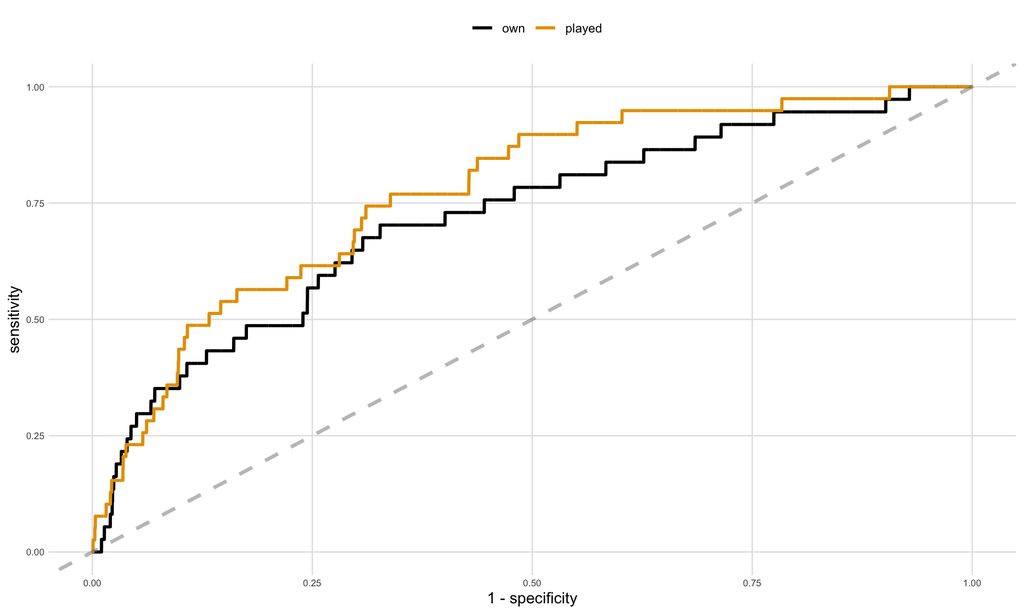

Another way to think about the model performance is to view its lift, or its ability to detect the positive outcomes over that of a null model. High lift indicates the model can much more quickly find all of the positive outcomes (in this case, games owned or played by the user), while a model with no lift is no better than random guessing.

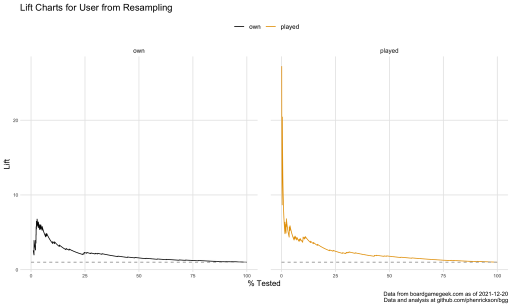

## 3.3 Most and Least Likely Games

What games does the model think Shauneh393 is **most likely to own** that are **not** in their collection?

| username | yearpublished | game_id | name | pred_own | actual_own |
| --- | --- | --- | --- | --- | --- |
| Shauneh393 | 2005 | 15062 | Shadows over Camelot | 0.49 | 0 |
| Shauneh393 | 2012 | 122515 | Keyflower | 0.43 | 0 |
| Shauneh393 | 2011 | 70919 | Takenoko | 0.41 | 0 |
| Shauneh393 | 2018 | 258444 | Gingerbread House | 0.30 | 0 |
| Shauneh393 | 2018 | 205896 | Rising Sun | 0.25 | 0 |

What games does the model think Shauneh393 is **least likely to own** that **are** in their collection?

| username | yearpublished | game_id | name | pred_own | actual_own |
| --- | --- | --- | --- | --- | --- |
| Shauneh393 | 2003 | 6187 | Avalon | 0 | 1 |
| Shauneh393 | 2015 | 173346 | 7 Wonders Duel | 0 | 1 |
| Shauneh393 | 2019 | 264241 | Mandala | 0 | 1 |
| Shauneh393 | 2011 | 84876 | The Castles of Burgundy | 0 | 1 |
| Shauneh393 | 2017 | 195162 | Plague Inc.: The Board Game | 0 | 1 |

## 3.4 Top Games by Year

Top 25 games most likely to be owned by the user in each year, highlighting in blue the games that the user has owned/played.

| rank | 2011 | 2012 | 2013 | 2014 | 2015 | 2016 | 2017 | 2018 | 2019 |
| --- | --- | --- | --- | --- | --- | --- | --- | --- | --- |
| 1 | Takenoko | Keyflower | Patchistory | Deception: Murder in Hong Kong | Grand Austria Hotel | Kingdomino | Gaia Project | Gingerbread House | Barrage |
| 2 | Ora et Labora | Suburbia | The Ravens of Thri Sahashri | Five Tribes | Broom Service | When I Dream | Fog of Love | Rising Sun | Queenz: To Bee or Not to Bee |
| 3 | Mundus Novus | Space Cadets | Longhorn | Madame Ching | Raptor | The Oregon Trail Card Game | Magic Maze | Everdell | The Magnificent |
| 4 | Shitenno | Milestones | Lewis & Clark: The Expedition | Subdivision | 504 | Yokohama | Codenames: Duet | The Grizzled: Armistice Edition | Era: Medieval Age |
| 5 | Tragedy Looper | Robinson Crusoe: Adventures on the Cursed Island | Bomb Squad | Spyfall | Mysterium | Assembly | Muse | Newton | Clank!: Legacy – Acquisitions Incorporated |
| 6 | Discworld: Ankh-Morpork | Terra Mystica | Legacy: The Testament of Duke de Crecy | Sheriff of Nottingham | Between Two Cities | The Networks | Mountains of Madness | Yellow & Yangtze | Sierra West |
| 7 | A Few Acres of Snow | Dark Horse | Concept | Castles of Mad King Ludwig | The Pursuit of Happiness | 13 Days: The Cuban Missile Crisis | Montana | Azul: Stained Glass of Sintra | Minecraft: Builders & Biomes |
| 8 | PAX | Trains | Tajemnicze Domostwo | Haru Ichiban | Discoveries: The Journals of Lewis & Clark | Agricola (Revised Edition) | Gloomhaven | Underwater Cities | Paris: La Cité de la Lumière |
| 9 | Airlines Europe | Qin | Citrus | Witness | The King Is Dead | HMS Dolores | Paper Tales | Treasure Island | Maracaibo |
| 10 | The City | Würfelwurst | Palmyra | Doodle City | New York 1901 | Citadels | The Castles of Burgundy: The Dice Game | Decrypto | Amul |
| 11 | Sekigahara: The Unification of Japan | Rumble in the Dungeon | Glass Road | Don't Mess with Cthulhu | Mombasa | Codenames: Pictures | Photosynthesis | Kero | Space Gate Odyssey |
| 12 | City Square Off | Zug um Zug: Deutschland | Eight-Minute Empire: Legends | Port Royal | The Grizzled | Heir to the Pharaoh | Azul | Lords of Hellas | Obscurio |
| 13 | Friday | Tokaido | Sanssouci | Dragon Run | The Game | Scythe | Tybor the Builder | Sprawlopolis | Hadara |
| 14 | Martian Dice | Eight-Minute Empire | The Phantom Society | Patchwork | ...and then, we held hands. | Kanagawa | Breaking Bad: The Board Game | Pax Emancipation | Medium |
| 15 | Principato | Escape: The Curse of the Temple | Händler der Karibik | Imperial Settlers | Trambahn | Islebound | Codenames: Disney – Family Edition | Blue Lagoon | Coloma |
| 16 | Helvetia | Targi | Caverna: The Cave Farmers | Sons of Anarchy: Men of Mayhem | Sylvion | Beyond Baker Street | Santo Domingo | Founders of Gloomhaven | One Key |
| 17 | The Gnomes of Zavandor | Agricola: All Creatures Big and Small | Circus Train (Second Edition) | Viceroy | Daxu | Sushi Go Party! | Sunflower Valley | Just One | It's a Wonderful World |
| 18 | Village | Le Havre: The Inland Port | The Little Prince: Make Me a Planet | DungeonQuest Revised Edition | Inhabit the Earth | Broom Service: The Card Game | Century: Spice Road | Renegade | DinoGenics |
| 19 | Feudalia | Polis: Fight for the Hegemony | Sushi Go! | San Juan (Second Edition) | Gold West | Medici: The Card Game | The Shipwreck Arcana | Root | Quirky Circuits |
| 20 | Gears of War: The Board Game | Urbion | Dungeon Twister: The Card Game | Sultaniya | The Bloody Inn | Black Orchestra | Smash Up: What Were We Thinking? | Coimbra | Atlantis Rising (Second Edition) |
| 21 | Ascending Empires | Might & Magic Heroes | Dungeon Heroes | Mythotopia | Oh My Goods! | Costa Rica | Raging Bulls | Age of Towers | Tiny Towns |
| 22 | Ninjato | War of the Ring: Second Edition | Hoplomachus: Rise of Rome | Ivor the Engine | Dead Man's Draw | Pandemic: Iberia | Mythic Battles: Pantheon | Solenia | Letter Jam |
| 23 | Pastiche | Star Trek: Catan | Le Fantôme de l'Opéra | Yardmaster Express | The Voyages of Marco Polo | Terraforming Mars | Pulsar 2849 | Fuji | Cartographers |
| 24 | Walnut Grove | Kingdom of Solomon | The Hunters: German U-Boats at War, 1939-43 | Heroes of Normandie | Tales & Games: Little Red Riding Hood | Exceed Fighting System | Valletta | Space Park | Ragusa |
| 25 | Tournay | Wiz-War (Eighth Edition) | Cube Quest | Smash Up: Science Fiction Double Feature | FUSE | 1572: The Lost Expedition | Rajas of the Ganges | Street Masters | De Vulgari Eloquentia: Deluxe Edition |

## 3.5 Interactive Predictions from Resampling

Interactive table for predictions from resampling.

|  | username | yearpublished | rank | game_id | name | pred_played | pred_own | actual_played | actual_own |
| --- | --- | --- | --- | --- | --- | --- | --- | --- | --- |
| 1 | Shauneh393 | 1900 | 152 | 10799 | Old Maid | 0.08 | 0.03 | 0 | 0 |
| 2 | Shauneh393 | 1900 | 302 | 11670 | The Game of Authors | 0.05 | 0.02 | 0 | 0 |
| 3 | Shauneh393 | 1900 | 420 | 3886 | Nine Men's Morris | 0 | 0.01 | 0 | 0 |
| 4 | Shauneh393 | 1900 | 466 | 10400 | Patience | 0 | 0.01 | 0 | 0 |
| 5 | Shauneh393 | 1900 | 1124 | 2136 | Pachisi | 0 | 0.01 | 0 | 0 |
| 6 | Shauneh393 | 1900 | 1125 | 6424 | Pick Up Sticks | 0 | 0.01 | 0 | 0 |
| 7 | Shauneh393 | 1900 | 1454 | 5546 | Marbles | 0 | 0 | 0 | 0 |
| 8 | Shauneh393 | 1900 | 1457 | 11901 | Tic-Tac-Toe | 0 | 0 | 0 | 0 |
| 9 | Shauneh393 | 1900 | 1506 | 188 | Go | 0 | 0 | 0 | 0 |
| 10 | Shauneh393 | 1900 | 1614 | 171 | Chess | 0 | 0 | 0 | 0 |

[output cut: 7426 more lines]

# 4 Validating the Model on 2020

How well did a model trained on a user’s collection through 2019 perform in predicting games for the user from 2020?

| username | outcome_type | yearpublished | .metric | .estimator | .estimate |
| --- | --- | --- | --- | --- | --- |
| Shauneh393 | own | 2020 | roc_auc | binary | 0.894 |
| Shauneh393 | played | 2020 | roc_auc | binary | 0.855 |

Table of top 25 games from 2020, highlighting games that the user owns.

| username | yearpublished | game_id | name | pred_own | pred_played | actual_own | actual_played |
| --- | --- | --- | --- | --- | --- | --- | --- |
| Shauneh393 | 2020 | 184267 | On Mars | 0.52 | 0.64 | 0 | 0 |
| Shauneh393 | 2020 | 291457 | Gloomhaven: Jaws of the Lion | 0.24 | 0.30 | 1 | 1 |
| Shauneh393 | 2020 | 300322 | Hallertau | 0.14 | 0.20 | 0 | 0 |
| Shauneh393 | 2020 | 302310 | Nanaki | 0.08 | 0.07 | 0 | 0 |
| Shauneh393 | 2020 | 320819 | Dinner in Paris | 0.07 | 0.08 | 0 | 0 |
| Shauneh393 | 2020 | 288513 | Tranquility | 0.05 | 0.05 | 0 | 0 |
| Shauneh393 | 2020 | 291511 | Medici: The Dice Game | 0.05 | 0.05 | 0 | 0 |
| Shauneh393 | 2020 | 306481 | Tawantinsuyu: The Inca Empire | 0.05 | 0.02 | 0 | 0 |
| Shauneh393 | 2020 | 227224 | The Red Cathedral | 0.04 | 0.05 | 0 | 0 |
| Shauneh393 | 2020 | 229782 | Roland Wright: The Dice Game | 0.04 | 0.04 | 0 | 0 |
| Shauneh393 | 2020 | 256317 | Guild Master | 0.04 | 0.06 | 0 | 0 |
| Shauneh393 | 2020 | 256509 | The One Hundred Torii | 0.04 | 0.03 | 0 | 0 |
| Shauneh393 | 2020 | 281075 | Welcome to New Las Vegas | 0.04 | 0.03 | 0 | 0 |
| Shauneh393 | 2020 | 296151 | Viscounts of the West Kingdom | 0.04 | 0.05 | 0 | 0 |
| Shauneh393 | 2020 | 298371 | Wild Space | 0.04 | 0.03 | 0 | 0 |
| Shauneh393 | 2020 | 302840 | Carcata | 0.04 | 0.07 | 0 | 0 |
| Shauneh393 | 2020 | 319966 | The King Is Dead: Second Edition | 0.04 | 0.03 | 0 | 0 |
| Shauneh393 | 2020 | 323784 | Ghost Letters | 0.04 | 0.03 | 0 | 0 |
| Shauneh393 | 2020 | 248125 | Monumental | 0.03 | 0.03 | 0 | 0 |
| Shauneh393 | 2020 | 260694 | Catacombs Cubes | 0.03 | 0.02 | 0 | 0 |
| Shauneh393 | 2020 | 283155 | Calico | 0.03 | 0.03 | 0 | 0 |
| Shauneh393 | 2020 | 284742 | Honey Buzz | 0.03 | 0.02 | 0 | 0 |
| Shauneh393 | 2020 | 292333 | Cowboys II: Cowboys & Indians Edition | 0.03 | 0.04 | 0 | 0 |
| Shauneh393 | 2020 | 295957 | Holi: Festival of Colors | 0.03 | 0.04 | 0 | 0 |
| Shauneh393 | 2020 | 301716 | Glasgow | 0.03 | 0.04 | 0 | 0 |

# 5 Predicting Upcoming Games (2020 and On) for **Shauneh393**

Examine the top games for the test set.

| username | yearpublished | game_id | name | rank | own | played |
| --- | --- | --- | --- | --- | --- | --- |
| Shauneh393 | 2020 | 184267 | On Mars | 1 | 0.52 | 0.64 |
| Shauneh393 | 2020 | 291457 | Gloomhaven: Jaws of the Lion | 2 | 0.24 | 0.30 |
| Shauneh393 | 2020 | 300322 | Hallertau | 3 | 0.14 | 0.20 |
| Shauneh393 | 2020 | 302310 | Nanaki | 4 | 0.08 | 0.07 |
| Shauneh393 | 2020 | 320819 | Dinner in Paris | 5 | 0.07 | 0.08 |
| Shauneh393 | 2020 | 306481 | Tawantinsuyu: The Inca Empire | 6 | 0.05 | 0.02 |
| Shauneh393 | 2020 | 291511 | Medici: The Dice Game | 7 | 0.05 | 0.05 |
| Shauneh393 | 2020 | 288513 | Tranquility | 8 | 0.05 | 0.05 |
| Shauneh393 | 2020 | 323784 | Ghost Letters | 9 | 0.04 | 0.03 |
| Shauneh393 | 2020 | 256509 | The One Hundred Torii | 10 | 0.04 | 0.03 |
| Shauneh393 | 2020 | 256317 | Guild Master | 11 | 0.04 | 0.06 |
| Shauneh393 | 2020 | 298371 | Wild Space | 12 | 0.04 | 0.03 |
| Shauneh393 | 2020 | 227224 | The Red Cathedral | 13 | 0.04 | 0.05 |
| Shauneh393 | 2020 | 281075 | Welcome to New Las Vegas | 14 | 0.04 | 0.03 |
| Shauneh393 | 2020 | 302840 | Carcata | 15 | 0.04 | 0.07 |
| Shauneh393 | 2020 | 229782 | Roland Wright: The Dice Game | 16 | 0.04 | 0.04 |
| Shauneh393 | 2020 | 319966 | The King Is Dead: Second Edition | 17 | 0.04 | 0.03 |
| Shauneh393 | 2020 | 296151 | Viscounts of the West Kingdom | 18 | 0.04 | 0.05 |
| Shauneh393 | 2020 | 260694 | Catacombs Cubes | 19 | 0.03 | 0.02 |
| Shauneh393 | 2020 | 308765 | Praga Caput Regni | 20 | 0.03 | 0.03 |
| Shauneh393 | 2020 | 312965 | Hogs of War: The Miniatures Game | 21 | 0.03 | 0.03 |
| Shauneh393 | 2020 | 316377 | 7 Wonders (Second Edition) | 22 | 0.03 | 0.03 |
| Shauneh393 | 2020 | 311193 | Anno 1800 | 23 | 0.03 | 0.02 |
| Shauneh393 | 2020 | 284742 | Honey Buzz | 24 | 0.03 | 0.02 |
| Shauneh393 | 2020 | 248125 | Monumental | 25 | 0.03 | 0.03 |
| Shauneh393 | 2021 | 298102 | Roll Camera!: The Filmmaking Board Game | 1 | 0.60 | 0.63 |
| Shauneh393 | 2021 | 343905 | Boonlake | 2 | 0.20 | 0.27 |
| Shauneh393 | 2021 | 282776 | Tumble Town | 3 | 0.19 | 0.19 |
| Shauneh393 | 2021 | 249277 | Brazil: Imperial | 4 | 0.11 | 0.10 |
| Shauneh393 | 2021 | 329593 | Settlement | 5 | 0.11 | 0.13 |
| Shauneh393 | 2021 | 319999 | Dungeon Decorators | 6 | 0.09 | 0.14 |
| Shauneh393 | 2021 | 310873 | Carnegie | 7 | 0.07 | 0.10 |
| Shauneh393 | 2021 | 342942 | Ark Nova | 8 | 0.06 | 0.05 |
| Shauneh393 | 2021 | 314088 | Agropolis | 9 | 0.05 | 0.09 |
| Shauneh393 | 2021 | 300217 | Merchants of the Dark Road | 10 | 0.04 | 0.03 |
| Shauneh393 | 2021 | 317504 | Mandala Stones | 11 | 0.04 | 0.03 |
| Shauneh393 | 2021 | 324856 | The Crew: Mission Deep Sea | 12 | 0.04 | 0.04 |
| Shauneh393 | 2021 | 323118 | Crack the Code | 13 | 0.04 | 0.05 |
| Shauneh393 | 2021 | 320446 | Corduba 27 a.C. | 14 | 0.04 | 0.04 |
| Shauneh393 | 2021 | 332944 | Sobek: 2 Players | 15 | 0.04 | 0.03 |
| Shauneh393 | 2021 | 295947 | Cascadia | 16 | 0.04 | 0.06 |
| Shauneh393 | 2021 | 295607 | Canopy | 17 | 0.04 | 0.03 |
| Shauneh393 | 2021 | 335541 | We Care: a Grizzled Game | 18 | 0.04 | 0.03 |
| Shauneh393 | 2021 | 329002 | CULTivate | 19 | 0.03 | 0.02 |
| Shauneh393 | 2021 | 336552 | Mystic Paths | 20 | 0.03 | 0.02 |
| Shauneh393 | 2021 | 275044 | Glow | 21 | 0.03 | 0.02 |
| Shauneh393 | 2021 | 346965 | Azul: Queen's Garden | 22 | 0.03 | 0.03 |
| Shauneh393 | 2021 | 315624 | World Changers | 23 | 0.03 | 0.04 |
| Shauneh393 | 2021 | 310031 | Whale Riders: The Card Game | 24 | 0.03 | 0.02 |
| Shauneh393 | 2021 | 305761 | Whale Riders | 25 | 0.03 | 0.02 |
| Shauneh393 | 2022 | 295770 | Frosthaven | 1 | 0.15 | 0.17 |
| Shauneh393 | 2022 | 334065 | Verdant | 2 | 0.11 | 0.17 |
| Shauneh393 | 2022 | 305096 | Endless Winter: Paleoamericans | 3 | 0.09 | 0.11 |
| Shauneh393 | 2022 | 317511 | Tindaya | 4 | 0.07 | 0.09 |
| Shauneh393 | 2022 | 304051 | Creature Comforts | 5 | 0.07 | 0.07 |
| Shauneh393 | 2022 | 335427 | Wild: Serengeti | 6 | 0.06 | 0.05 |
| Shauneh393 | 2022 | 258779 | Planet Unknown | 7 | 0.05 | 0.06 |
| Shauneh393 | 2022 | 280726 | Legacies | 8 | 0.04 | 0.05 |
| Shauneh393 | 2022 | 319807 | Shogun no Katana | 9 | 0.03 | 0.03 |
| Shauneh393 | 2022 | 336986 | Flamecraft | 10 | 0.03 | 0.03 |
| Shauneh393 | 2022 | 326945 | Castles of Mad King Ludwig: Collector's Edition | 11 | 0.03 | 0.04 |
| Shauneh393 | 2022 | 331106 | The Witcher: Old World | 12 | 0.03 | 0.04 |
| Shauneh393 | 2022 | 348463 | ECO: Coral Reef | 13 | 0.02 | 0.01 |
| Shauneh393 | 2022 | 322589 | Zapotec | 14 | 0.02 | 0.02 |
| Shauneh393 | 2022 | 305462 | The Age of Atlantis | 15 | 0.02 | 0.02 |
| Shauneh393 | 2022 | 295374 | Long Shot: The Dice Game | 16 | 0.02 | 0.03 |
| Shauneh393 | 2022 | 322524 | Bardsung | 17 | 0.02 | 0.03 |
| Shauneh393 | 2022 | 324090 | Scarface 1920 | 18 | 0.02 | 0.02 |
| Shauneh393 | 2022 | 318450 | Bios: Mesofauna | 19 | 0.01 | 0.01 |
| Shauneh393 | 2022 | 271601 | Feed the Kraken | 20 | 0.01 | 0.01 |
| Shauneh393 | 2022 | 277025 | Vampire: The Masquerade – CHAPTERS | 21 | 0.01 | 0.01 |
| Shauneh393 | 2022 | 256997 | Perseverance: Castaway Chronicles – Episodes 1 & 2 | 22 | 0.01 | 0.01 |
| Shauneh393 | 2022 | 266018 | Trinidad | 23 | 0.01 | 0.01 |
| Shauneh393 | 2022 | 340325 | Vagrantsong | 24 | 0.01 | 0.00 |
| Shauneh393 | 2022 | 294529 | Entropia: The Game | 25 | 0.01 | 0.01 |

## 5.1 Interactive Table for Upcoming Games 2020 and On

|  | username | yearpublished | game_id | name | rank | own | played |
| --- | --- | --- | --- | --- | --- | --- | --- |
| 1 | Shauneh393 | 2021 | 298102 | Roll Camera!: The Filmmaking Board Game | 1 | 0.6 | 0.63 |
| 2 | Shauneh393 | 2020 | 184267 | On Mars | 2 | 0.52 | 0.64 |
| 3 | Shauneh393 | 2020 | 291457 | Gloomhaven: Jaws of the Lion | 3 | 0.24 | 0.3 |
| 4 | Shauneh393 | 2021 | 343905 | Boonlake | 4 | 0.2 | 0.27 |
| 5 | Shauneh393 | 2021 | 282776 | Tumble Town | 5 | 0.19 | 0.19 |
| 6 | Shauneh393 | 2022 | 295770 | Frosthaven | 6 | 0.15 | 0.17 |
| 7 | Shauneh393 | 2020 | 300322 | Hallertau | 7 | 0.14 | 0.2 |
| 8 | Shauneh393 | 2021 | 249277 | Brazil: Imperial | 8 | 0.11 | 0.1 |
| 9 | Shauneh393 | 2021 | 329593 | Settlement | 9 | 0.11 | 0.13 |
| 10 | Shauneh393 | 2022 | 334065 | Verdant | 10 | 0.11 | 0.17 |

[output cut: 1627 more lines]